# Welcome to MUSA 620: Geospatial Data Science in Python

## My day job

- My name is Nick Hand
- I am the Director of Finance, Data, and Policy for City Controller Rebecca Rhynhart
- Goals of our team:
  - objective, data-driven analysis of financial policies impacting Philadelphia
  - increasing transparency through data releases and interactive reports
- Recent projects:
  - Analysis of the fairness and accuracy of property assessments
  - [Interactive reports for the City's cash levels](https://controller.phila.gov/philadelphia-audits/cash-report-fiscal-year-2019-q3/)
  - Analysis of the 10-Year Tax Abatement program
  - [Interactive dashboard of Soda Tax spending](https://controller.phila.gov/philadelphia-audits/data-release-beverage-tax/)
  - [Visualization of paving & potholes](https://controller.phila.gov/philadelphia-audits/data-release-paving-and-potholes/)
  - [Visualization of the City's diversity](https://controller.phila.gov/philadelphia-audits/fy18-exempt-employee-diversity/)
- Check out https://controller.phila.gov/policy-analysis

[figure not shown]

## Previously: Astrophysics Ph.D. at Berkeley

[figure not shown]

## How did I get here?

- Astrophysics to data science is becoming increasingly common
- Landing a job through Twitter: https://www.parkingjawn.com
  - Dashboard visualization of monthly parking tickets in Philadelphia
  - Data from [OpenDataPhilly](https://www.opendataphilly.org/)

**Goal: exploring and extracting insight from complex datasets**

## Parking Jawn

- https://www.parkingjawn.com
- Cross-filtering
- Different views
- See drop in parking tickets over Jan 24-26, 2016 due to snowstorm

# Class logistics

## General info

- 3-hour classes — mix of lecturing, interactive demos, and in-class lab time
- short break about halfway through
- My email: nhand@design.upenn.edu
  - Office Hours:
    - 2-hours during the week
    - Time is TBD
- Teaching Assistant: Chloe Sheen
  - Email: csheen1@sas.upenn.edu
  - Office hours: TBD

## Course GitHub

- https://github.com/MUSA-620-Fall-2019
- Hosting lectures & assignments
- Assignments will be submitted here too

[figure not shown]

## Course materials repository

- https://www.github.com/MUSA-620-Fall-2019/course-materials
- Contains:
  - [the syllabus](https://github.com/MUSA-620-Fall-2019/course-materials/blob/master/syllabus.md)
  - [reference materials and FAQ on setting up Python](https://github.com/MUSA-620-Fall-2019/course-materials/tree/master/anaconda-guide) (more on this later)
  - [introductory tutorials for learning Python](https://github.com/MUSA-620-Fall-2019/course-materials#recommended-python-tutorials) (more on this later, too)

## Piazza

- https://piazza.com/upenn/fall2019/musa620/home
- Forum for asking questions on materials and homework assignments
- Will factor into your participation grade

**Important: don't post lengthy screenshots of your code publicly — use private post and we will respond**

## The goals of this course

- Provide students with the knowledge and tools to turn data into meaningful insights and stories
- Focus on the modern data science tools within the Python ecosystem
- The pipeline approach to data science:
  - gathering, storing, analyzing, and visualizing data to tell stories
- Real-world applications of analysis techniques in the urban planning and public policy realm

## What we'll cover

### Module 1

**Exploratory Data Science:** Students will be introduced to the main tools needed to get started analyzing and visualizing data using Python

### Module 2

**Introduction to Geospatial Data Science:** Building on the previous set of tools, this module will teach students how to work with geospatial datasets using a range of modern Python toolkits.

### Module 3

**Data Ingestion & Big Data:** Students will learn how to collect new data through web scraping and APIs, as well as how to work effectively with the large datasets often encountered in real-world applications.

### Module 4

**Geospatial Data Science in the Wild:** Armed with the necessary data science tools, students will be introduced to a range of advanced analytic and machine learning techniques using a number of innovative examples from modern researchers.

### Module 5

**From Exploration to Storytelling:** The final module will teach students to present their analysis results using web-based formats to transform their insights into interactive stories.

## Assignments and grading

- Grading:
  - 50% homework
  - 40% final project
  - 10% participation (based on both in-class participation and on Piazza)
- Late policy: accepted up to 1 week late with a 10% deduction

Homeworks will be assigned (roughly) every two weeks. You must complete five of the seven homework assignments. Four of the assignments are required, and you are allowed to choose the last assignment to complete (out of the remaining three options).

[figure not shown]

## Final Project

The final project is to replicate the pipeline approach on a dataset (or datasets) of your choosing.

Students will be required to use several of the analysis techniques taught in the class and produce a web-based data visualization that effectively communicates the empirical results to a non-technical audience.

## Initial survey

https://www.surveymonkey.com/r/BGK3S6Y

### Okay, let's get started...

## The Incredible Growth of Python

[A StackOverflow analysis](https://stackoverflow.blog/2017/09/06/incredible-growth-python/)

[figure not shown]

## The rise of the Jupyter notebook

## The engine of collaborative data science

- First started by a physics grad student around 2001
- Known as the IPython notebook originally
- Starting getting popular in ~2011
- First funding received in 2015 $\rightarrow$ the Jupyter notebook was born

### Google searches for Jupyter notebook

[figure not shown]

## Key features

- Aimed at "computational narratives" — telling stories with data
- interactive, reproducible, shareable, user-friendly, visualization-focused

**very versatile: good for both exploratory data analysis and polished finished products**

## Beyond the Jupyter notebook

### Google's Colaboratory

[figure not shown]

- A fancier notebook experience built on top of Jupyter notebook
- Running in the cloud on Google's servers
- An internal Google product that was recently released publicly
- Very popular for Python-based machine learning
- Won't need to use much in this course

See https://colab.research.google.com/notebooks/welcome.ipynb

## Binder: https://mybinder.org

[figure not shown]

### Allows you to launch a repository of Jupyter notebooks on GitHub in the cloud

Note: as a free service, it can be a bit slow sometimes

### Weekly lectures are available on Binder

[figure not shown]

### Weekly Workflow

1. Setup local Python environment as part of first homework assignment (week 1)
2. Follow along on lectures using Binder in the cloud
3. Install new Python dependencies each week into your local environment so you can work on homeworks locally

To follow along, go to https://github.com/MUSA-620-Fall-2019/week-1

## Now to the fun stuff...

These slides are a Jupyter notebook.

A mix of *code* cells and **text** cells in Markdown. Change the type of cell in the top menu bar.

```python
# A simple code cell
# SHIFT-ENTER to execute

x = 10
print(x)
```

```
10
```

### Python data types

```python
# integer
a = 10

# float
b = 10.5

# string
c = "this is a test string"

# lists
d = list(range(10))

# booleans
e = True

# dictionaries
f = {'key1': 1, "key2": 2}
```

```python
print(a)
print(b)
print(c)
print(d)
print(e)
print(f)
```

```
10
10.5
this is a test string
[0, 1, 2, 3, 4, 5, 6, 7, 8, 9]
True
{'key1': 1, 'key2': 2}
```

### Alternative method for creating a dictionary

```python
f = dict(key1=1, key2=2, key3=3)
```

### Accessing dictionary values

```python
# access the value with key 'key1'
f['key1']
```

```
1
```

### Accessing list values

```python
# access the second list entry (0 is the first index)
d[1]
```

```
1
```

### Accessing characters of a string

```python
# the first character
c[0]
```

```
't'
```

### Iterators and for loops

```python
# Python code
result = 0
for i in range(100):
    result = result + i
```

```python
print(result)
```

```
4950
```

### Python's inline syntax

```python
a = range(10) # this is an iterator
```

```python
print(a)
```

```
range(0, 10)
```

```python
# convert it to a list explicitly
a = list(range(10))
print(a)
```

```
[0, 1, 2, 3, 4, 5, 6, 7, 8, 9]
```

```python
# or use the INLINE syntax; this is the SAME
a = [i for i in range(10)]
print(a)
```

```
[0, 1, 2, 3, 4, 5, 6, 7, 8, 9]
```

### Python functions

```
def function_name(arg1, arg2, arg3):

    .
    .
    .
    code lines (indented)
    .
    .
    .

    return result
```

```python
def compute_square(x):

    return x * x
```

```python
sq = compute_square(5)
print(sq)
```

```
25
```

### Keywords: arguments with a default!

```python
def compute_product(x, y=5):

    return x * y
```

```python
# use the default value for y
print(compute_product(5))
```

```
25
```

```python
# specify a y value other than the default
print(compute_product(5, 10))
```

```
50
```

```python
# can also explicitly tell Python which arguments are which
print(compute_product(5, y=2))
print(compute_product(x=5, y=2))
```

```
10
10
```

```python
# argument names must match the function signature though!
print(compute_product(5, z=5))
```

```
---------------------------------------------------------------------------
TypeError                                 Traceback (most recent call last)
<ipython-input-40-5db83a932315> in <module>
      1 # argument names must match the function signature though!
----> 2 print(compute_product(5, z=5))

TypeError: compute_product() got an unexpected keyword argument 'z'
```

### Getting help in the notebook

Use tab auto-completion and the ? and ?? operators

```python
this_variable_has_a_long_name = 5
```

```python
# try hitting tab after typing this_
this_variable_has_a_long_name
```

```
5
```

```python
# try typing "r" and then tab
```

```python
# Forget how to create a range? --> use the help message
range?
```

### Peeking at the source code for a function

Use the ?? operator

```python
compute_product??
```

The question mark operator gives you access to the help message for any variable or function. **Very useful**

## Getting more Python help

This was a **very** brief introduction. Additional Python tutorials listed on this week's README and on the course materials page.

- https://bids.github.io/2016-01-14-berkeley/python/00-python-intro.html ([notebook version](https://bids.github.io/2016-01-14-berkeley/python/00-python-intro.ipynb))
- [Python for Social Science, a free online book](https://gawron.sdsu.edu/python_for_ss/course_core/book_draft/index.html)
- Many more resources are listed here: http://python.berkeley.edu/resources/

## The Data Science Handbook

The [The Python Data Science Handbook](https://jakevdp.github.io/PythonDataScienceHandbook/) is a free, online textbook covering the Python basics needed in this course. In particular, the first four chapters are excellent:

- [Chapter 1: IPython/Jupyter](https://jakevdp.github.io/PythonDataScienceHandbook/01.00-ipython-beyond-normal-python.html)
- [Chapter 2: Numpy](https://jakevdp.github.io/PythonDataScienceHandbook/02.00-introduction-to-numpy.html)
- [Chapter 3: Pandas](https://jakevdp.github.io/PythonDataScienceHandbook/03.00-introduction-to-pandas.html)
- [Chapter 4: matplotlib](https://jakevdp.github.io/PythonDataScienceHandbook/04.00-introduction-to-matplotlib.html)

Note that you can click on the "Open in Colab" button for each chapter and run the examples interactively using [Google Colab](https://colab.research.google.com).

## Python Data Analysis: the *pandas* package

Documentation is available at https://pandas.pydata.org

[figure not shown]

The following line imports the *pandas* package:

```python
import pandas as pd
```

## Basic *pandas* concepts

The primary *objects* in *pandas* are the:

- **`DataFrame`**, which is very similar to an Excel spreadsheet, and has rows and named columns
- **`Series`**, which represents a single column of data. A `DataFrame` contains one or more `Series` and a name for each `Series`.

The data frame is a commonly used abstraction for data manipulation. Similar implementations exist in [R](https://www.r-project.org/about.html).

You can think `Series` objects as fancier versions of Python's built-in list data type

To create a `Series` object:

```python
# city names and population
city_names = pd.Series(['San Francisco', 'San Jose', 'Sacramento'])
population = pd.Series([852469, 1015785, 485199])
```

```python
city_names
```

```
0    San Francisco
1         San Jose
2       Sacramento
dtype: object
```

`DataFrame` objects can be created by passing a `dict` mapping `string` column names to their respective `Series`.

```python
df = pd.DataFrame({ 'City Name': city_names, 'Population': population })
df
```

|  | City Name | Population |
| --- | --- | --- |
| 0 | San Francisco | 852469 |
| 1 | San Jose | 1015785 |
| 2 | Sacramento | 485199 |

## Accessing data

```python
# access columns with a dict-like syntax
df['Population']
```

```
0     852469
1    1015785
2     485199
Name: Population, dtype: int64
```

### Rows can be accessed using Python's syntax for slicing

```python
# list slicing: get the elements with indices 1 and 2 (but NOT 3)
cities = ['San Francisco', 'San Jose', 'Sacramento']
cities[1:3]
```

```
['San Jose', 'Sacramento']
```

```python
# slicing data frame rows is very similar!
df[1:3]
```

|  | City Name | Population |
| --- | --- | --- |
| 1 | San Jose | 1015785 |
| 2 | Sacramento | 485199 |

*pandas* includes functionality for many different ways of selecting data. See [the documentation](https://pandas.pydata.org/pandas-docs/stable/indexing.html) for many more examples.

## Manipulating data

```python
df['Population'].median()
```

```
852469.0
```

[NumPy](http://www.numpy.org/) is a popular toolkit for scientific computing.

*pandas* `Series` can be used as arguments to most NumPy functions:

```python
import numpy as np

# calculate the median population value
np.median(df['Population'])
```

```
852469.0
```

For more complex single-column transformations, you can use `Series.apply`. It accepts a function that is applied to each value in the `Series`.

For example, we can find which cities have a population greater than a million:

```python
# define our function
def get_large_cities(population):
    return population > 1e6

large_cities = df['Population'].apply(get_large_cities)
```

```python
large_cities
```

```
0    False
1     True
2    False
Name: Population, dtype: bool
```

```python
# add the new computed column to our original data frame
df['Large Cities'] = large_cities

# we can also use lambda (unnamed, inline) functions
df['Small Cities'] = df['Population'].apply(lambda population: population < 1e6)

# print out
df
```

|  | City Name | Population | Large Cities | Small Cities |
| --- | --- | --- | --- | --- |
| 0 | San Francisco | 852469 | False | True |
| 1 | San Jose | 1015785 | True | False |
| 2 | Sacramento | 485199 | False | True |

### Data selection

We can select the "large" cities by passing the boolean values to the `.loc()` function of a `DataFrame`:

```python
df['Large Cities']
```

```
0    False
1     True
2    False
Name: Large Cities, dtype: bool
```

```python
df.loc[df['Large Cities']]
```

|  | City Name | Population | Large Cities | Small Cities |
| --- | --- | --- | --- | --- |
| 1 | San Jose | 1015785 | True | False |

### There is a faster, more concise, to achieve this!

```python
df['Population'] > 1e6
```

```
0    False
1     True
2    False
Name: Population, dtype: bool
```

```python
# this is equivalent to doing
df.loc[df['Population'] > 1e6]
```

|  | City Name | Population | Large Cities | Small Cities |
| --- | --- | --- | --- | --- |
| 1 | San Jose | 1015785 | True | False |

The documentation is your best friend! How to get help?

```python
# use the question mark
pd.DataFrame.loc?
```

## Now onto a more interesting example...

## Analyzing trends in rentals rates over time

Let's load census data on rentals rates from the 2017 Amercian Community Survey.

We've stored the data locally in the comma-separated value (CSV) format. Later in the course, you'll learn how to download them directly using Python.

Use the `read_csv()` function from *pandas*. The first argument to `read_csv()` is the file path to load.

```python
df = pd.read_csv("./data/census/ACS_17_1YR_B25003.csv")
```

```python
df.head()
```

|  | GEO.id | GEO.id2 | GEO.display-label | HD01_VD01 | HD02_VD01 | HD01_VD02 | HD02_VD02 | HD01_VD03 | HD02_VD03 |
| --- | --- | --- | --- | --- | --- | --- | --- | --- | --- |
| 0 | 1600000US0107000 | 107000 | Birmingham city, Alabama | 90186 | 3374 | 40295 | 2507 | 49891 | 3372 |
| 1 | 1600000US0121184 | 121184 | Dothan city, Alabama | 25192 | 875 | 14935 | 763 | 10257 | 722 |
| 2 | 1600000US0135896 | 135896 | Hoover city, Alabama | 34058 | 1330 | 22913 | 1724 | 11145 | 1482 |
| 3 | 1600000US0137000 | 137000 | Huntsville city, Alabama | 84750 | 2687 | 46677 | 2948 | 38073 | 2680 |
| 4 | 1600000US0150000 | 150000 | Mobile city, Alabama | 78145 | 2673 | 41297 | 2323 | 36848 | 2325 |

Select certain columns and rename them:

```python
# columns we want
columns = ['GEO.display-label', 'HD01_VD01', 'HD01_VD03']
df2 = df[columns].copy()

# rename columns
df2.columns = ['City', 'Total', 'Rentals']

df2.head()
```

|  | City | Total | Rentals |
| --- | --- | --- | --- |
| 0 | Birmingham city, Alabama | 90186 | 49891 |
| 1 | Dothan city, Alabama | 25192 | 10257 |
| 2 | Hoover city, Alabama | 34058 | 11145 |
| 3 | Huntsville city, Alabama | 84750 | 38073 |
| 4 | Mobile city, Alabama | 78145 | 36848 |

```python
df2['Rental Rate'] = df2['Rentals'] / df2['Total'] * 100
```

```python
df2.head()
```

|  | City | Total | Rentals | Rental Rate |
| --- | --- | --- | --- | --- |
| 0 | Birmingham city, Alabama | 90186 | 49891 | 55.320116 |
| 1 | Dothan city, Alabama | 25192 | 10257 | 40.715306 |
| 2 | Hoover city, Alabama | 34058 | 11145 | 32.723589 |
| 3 | Huntsville city, Alabama | 84750 | 38073 | 44.923894 |
| 4 | Mobile city, Alabama | 78145 | 36848 | 47.153369 |

```python
len(df2)
```

```
608
```

We can select the largest cities by population using the `Series.isin()` function, which checks if each value in the `Series` is in the specified list.

```python
top_cities = ['Philadelphia city, Pennsylvania',
              'New York city, New York',
              'Los Angeles city, California',
              'Houston city, Texas',
              'Chicago city, Illinois',
              'Phoenix city, Arizona']

#selection =  # which rows are valid
df2.loc[df2['City'].isin(top_cities)] # select the valid rows
```

|  | City | Total | Rentals | Rental Rate |
| --- | --- | --- | --- | --- |
| 18 | Phoenix city, Arizona | 559155 | 245335 | 43.876027 |
| 94 | Los Angeles city, California | 1384851 | 878061 | 63.404727 |
| 275 | Chicago city, Illinois | 1047695 | 577430 | 55.114322 |
| 426 | New York city, New York | 3159674 | 2127881 | 67.344954 |
| 474 | Philadelphia city, Pennsylvania | 606142 | 309279 | 51.024182 |
| 525 | Houston city, Texas | 837686 | 479409 | 57.230155 |

## An aside about string formatting

Python uses the "%" operator to insert variable values into strings. For example, the file name of the data we want to load for 2017 is:

```python
year_str = "17"
path = "./data/census/ACS_%s_1YR_B25003.csv" % year_str
print(path)
```

```
./data/census/ACS_17_1YR_B25003.csv
```

See [this guide](https://www.learnpython.org/en/String_Formatting) on this type of string formatting for more info.

## Python f-strings

Python version 3.6 introduced a new and improved string formatting syntax, where the variable that is being inserted can be referenced directly using the variable name.

The variable name should be enclosed in curly braces inside the string:

```python
year_str = "17"
path = f"./data/census/ACS_{year_str}_1YR_B25003.csv"
print(path)
```

```
./data/census/ACS_17_1YR_B25003.csv
```

For more info: see [this guide](https://realpython.com/python-f-strings/)

### Now let's load data from 2005 to 2017:

```python
data = []
for year in range(2005, 2018):

    # read data for this year
    year_str = str(year) # convert integer value of "year" to a string
    year_str = year_str[2:] # extract the last two digits of the year string
    df = pd.read_csv(f"./data/census/ACS_{year_str}_1YR_B25003.csv")

    # columns we want
    columns = ['GEO.display-label', 'HD01_VD01', 'HD01_VD03']
    df = df[columns]

    # rename columns
    df.columns = ['City', 'Total', 'Rentals']

    # calculate the rental rate
    df['Rental Rate'] = df['Rentals'] / df['Total'] * 100

    # select the cities we want
    selection = df['City'].isin(top_cities)
    df = df.loc[selection]

    # add a column for the year
    df['Year'] = year

    # save
    data.append(df)

# combine all of the data frames into one along the row axis
data = pd.concat(data, axis=0)
```

```python
data.head()
```

|  | City | Total | Rentals | Rental Rate | Year |
| --- | --- | --- | --- | --- | --- |
| 13 | Phoenix city, Arizona | 503753 | 204914 | 40.677475 | 2005 |
| 75 | Los Angeles city, California | 1284124 | 771325 | 60.066240 | 2005 |
| 218 | Chicago city, Illinois | 1020605 | 525620 | 51.500825 | 2005 |
| 349 | New York city, New York | 3026196 | 2023924 | 66.880136 | 2005 |
| 393 | Philadelphia city, Pennsylvania | 565433 | 244792 | 43.292839 | 2005 |

## Basic plotting: `matplotlib`

Much more to come next week. For now, we'll use some very simple plotting commands with Python's main plotting libary `matplotlib`.

Import the library we'll use from `matplotlib`.

```python
from matplotlib import pyplot as plt
```

We'll use the `plt.plot()` function which plots a simple `x` vs `y` line.

```
Phoenix city, Arizona
Los Angeles city, California
Chicago city, Illinois
New York city, New York
Philadelphia city, Pennsylvania
Houston city, Texas
```

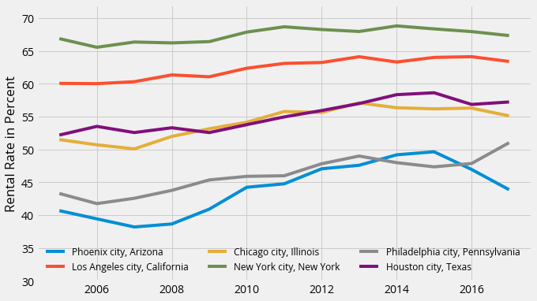

```python
with plt.style.context('fivethirtyeight'):
    for city in data['City'].unique():

        print(city)

        this_city = data['City'] == city
        df = data.loc[this_city]
        plt.plot(df['Year'], df['Rental Rate'], label=city)

# format
plt.legend(loc=0, ncol=3)
ax = plt.gca()
ax.set_ylim(30, 72)
ax.set_ylabel("Rental Rate in Percent")
ax.figure.set_size_inches((10, 6))
```

### From 2005 to 2017, Philadelphia had the largest percent increase

**Exercise**: can you calculate what the increase was for Philadelphia?

## Exercise solution

```python
# trim to just Philadelphia first, using this boolean selection index
data['City']=='Philadelphia city, Pennsylvania'
```

```
13     False
75     False
218    False
349    False
393     True
       ...
94     False
275    False
426    False
474     True
525    False
Name: City, Length: 78, dtype: bool
```

```python
# select Philadelphia only
philly = data.loc[data['City']=='Philadelphia city, Pennsylvania']
philly
```

|  | City | Total | Rentals | Rental Rate | Year |
| --- | --- | --- | --- | --- | --- |
| 393 | Philadelphia city, Pennsylvania | 565433 | 244792 | 43.292839 | 2005 |
| 400 | Philadelphia city, Pennsylvania | 554048 | 231323 | 41.751437 | 2006 |
| 408 | Philadelphia city, Pennsylvania | 562384 | 239363 | 42.562199 | 2007 |
| 415 | Philadelphia city, Pennsylvania | 578263 | 253084 | 43.766245 | 2008 |
| 419 | Philadelphia city, Pennsylvania | 569835 | 258459 | 45.356814 | 2009 |
| 427 | Philadelphia city, Pennsylvania | 575413 | 264129 | 45.902508 | 2010 |
| 434 | Philadelphia city, Pennsylvania | 576429 | 265126 | 45.994563 | 2011 |
| 437 | Philadelphia city, Pennsylvania | 579874 | 277323 | 47.824700 | 2012 |
| 449 | Philadelphia city, Pennsylvania | 582528 | 285430 | 48.998503 | 2013 |
| 454 | Philadelphia city, Pennsylvania | 577862 | 277301 | 47.987409 | 2014 |
| 458 | Philadelphia city, Pennsylvania | 581604 | 275397 | 47.351291 | 2015 |
| 465 | Philadelphia city, Pennsylvania | 580205 | 277707 | 47.863600 | 2016 |
| 474 | Philadelphia city, Pennsylvania | 606142 | 309279 | 51.024182 | 2017 |

### An aside about labels and the index in Panda

Note how the first row of the above dataframe has an index label of 393. This means we can access it using the `.loc[]` function like:

```python
philly.loc[393]
```

```
City           Philadelphia city, Pennsylvania
Total                                   565433
Rentals                                 244792
Rental Rate                            43.2928
Year                                      2005
Name: 393, dtype: object
```

This is different than the `.iloc[]` function, which also indexes based on the integer value of the row, regardless of what the labels in the index are. For example, the first row of a dataframe can always be accessed using:

```python
philly.iloc[0]
```

```
City           Philadelphia city, Pennsylvania
Total                                   565433
Rentals                                 244792
Rental Rate                            43.2928
Year                                      2005
Name: 393, dtype: object
```

We can reset the index labels so they range from 0 to the length of the dataframe, using the `reset_index()` function. For example

```python
philly.reset_index(drop=True)
```

|  | City | Total | Rentals | Rental Rate | Year |
| --- | --- | --- | --- | --- | --- |
| 0 | Philadelphia city, Pennsylvania | 565433 | 244792 | 43.292839 | 2005 |
| 1 | Philadelphia city, Pennsylvania | 554048 | 231323 | 41.751437 | 2006 |
| 2 | Philadelphia city, Pennsylvania | 562384 | 239363 | 42.562199 | 2007 |
| 3 | Philadelphia city, Pennsylvania | 578263 | 253084 | 43.766245 | 2008 |
| 4 | Philadelphia city, Pennsylvania | 569835 | 258459 | 45.356814 | 2009 |
| 5 | Philadelphia city, Pennsylvania | 575413 | 264129 | 45.902508 | 2010 |
| 6 | Philadelphia city, Pennsylvania | 576429 | 265126 | 45.994563 | 2011 |
| 7 | Philadelphia city, Pennsylvania | 579874 | 277323 | 47.824700 | 2012 |
| 8 | Philadelphia city, Pennsylvania | 582528 | 285430 | 48.998503 | 2013 |
| 9 | Philadelphia city, Pennsylvania | 577862 | 277301 | 47.987409 | 2014 |
| 10 | Philadelphia city, Pennsylvania | 581604 | 275397 | 47.351291 | 2015 |
| 11 | Philadelphia city, Pennsylvania | 580205 | 277707 | 47.863600 | 2016 |
| 12 | Philadelphia city, Pennsylvania | 606142 | 309279 | 51.024182 | 2017 |

Next, to calculate our percent difference we need to get the values for Philadelphia in 2005 and 2017:

```python
# select 2005
x = philly.loc[philly['Year']==2005]
value_2005 = x['Rental Rate'].iloc[0]
print("2005 value = ", value_2005)
```

```
2005 value =  43.292839293072745
```

```python
x['Rental Rate']
```

```
393    43.292839
Name: Rental Rate, dtype: float64
```

```python
# select 2017
y = philly.loc[philly['Year']==2017]
value_2017 = y['Rental Rate'].iloc[0]
print("2017 value = ", value_2017)
```

```
2017 value =  51.02418245229665
```

```python
# calculate percent change
percent_change = (value_2017 - value_2005)/ value_2005 * 100
```

```python
print("change in rental rate in Philadelphia from 2005 to 2017 = ", percent_change)
```

```
change in rental rate in Philadelphia from 2005 to 2017 =  17.85824927509661
```

For more details on the `iloc()` function, see the documentation on [indexing by position](https://pandas.pydata.org/pandas-docs/version/0.17.0/indexing.html#indexing-integer).

## Now let's compare Zillow rental and home value data

Load citywide Zillow Rent Index (ZRI) and Zillow Home Value Index (ZHVI) data.

Files were downloaded earlier from https://www.zillow.com/research/data/

```python
home_values = pd.read_csv("./data/zillow/Metro_Zhvi_AllHomes.csv", engine='python')
rent_values = pd.read_csv('./data/zillow/Metro_Zri_SingleFamilyResidenceRental.csv', engine='python')
```

Peek at the first few rows of the ZRI data:

```python
rent_values.head()
```

|  | RegionID | RegionName | SizeRank | 2010-11 | 2010-12 | 2011-01 | 2011-02 | 2011-03 | 2011-04 | 2011-05 | ... | 2018-02 | 2018-03 | 2018-04 | 2018-05 | 2018-06 | 2018-07 | 2018-08 | 2018-09 | 2018-10 | 2018-11 |
| --- | --- | --- | --- | --- | --- | --- | --- | --- | --- | --- | --- | --- | --- | --- | --- | --- | --- | --- | --- | --- | --- |
| 0 | 102001 | United States | 0 | 1250.0 | 1248.0 | 1245.0 | 1240.0 | 1236.0 | 1234.0 | 1236.0 | ... | 1411 | 1412 | 1414 | 1416 | 1416 | 1415 | 1415 | 1414 | 1417 | 1426 |
| 1 | 394913 | New York, NY | 1 | NaN | NaN | NaN | NaN | NaN | NaN | NaN | ... | 2422 | 2417 | 2417 | 2418 | 2417 | 2416 | 2415 | 2415 | 2425 | 2438 |
| 2 | 753899 | Los Angeles-Long Beach-Anaheim, CA | 2 | 2283.0 | 2272.0 | 2263.0 | 2259.0 | 2258.0 | 2263.0 | 2265.0 | ... | 2856 | 2866 | 2877 | 2886 | 2890 | 2892 | 2892 | 2893 | 2897 | 2911 |
| 3 | 394463 | Chicago, IL | 3 | 1581.0 | 1569.0 | 1560.0 | 1551.0 | 1541.0 | 1534.0 | 1530.0 | ... | 1698 | 1696 | 1696 | 1696 | 1695 | 1694 | 1694 | 1693 | 1697 | 1713 |
| 4 | 394514 | Dallas-Fort Worth, TX | 4 | 1297.0 | 1297.0 | 1297.0 | 1298.0 | 1298.0 | 1300.0 | 1304.0 | ... | 1624 | 1622 | 1622 | 1621 | 1619 | 1618 | 1618 | 1616 | 1620 | 1630 |

5 rows × 100 columns

And do the same for the ZHVI data:

```python
home_values.head()
```

|  | RegionID | RegionName | SizeRank | 1996-04 | 1996-05 | 1996-06 | 1996-07 | 1996-08 | 1996-09 | 1996-10 | ... | 2018-02 | 2018-03 | 2018-04 | 2018-05 | 2018-06 | 2018-07 | 2018-08 | 2018-09 | 2018-10 | 2018-11 |
| --- | --- | --- | --- | --- | --- | --- | --- | --- | --- | --- | --- | --- | --- | --- | --- | --- | --- | --- | --- | --- | --- |
| 0 | 102001 | United States | 0 | 100600.0 | 100600.0 | 100600.0 | 100700.0 | 100800.0 | 101000.0 | 101200.0 | ... | 211500 | 213200 | 214400 | 215600 | 216800 | 217900 | 219100 | 220200 | 221600 | 222800 |
| 1 | 394913 | New York, NY | 1 | 165000.0 | 164800.0 | 164600.0 | 164300.0 | 164100.0 | 163900.0 | 163800.0 | ... | 420800 | 423400 | 425300 | 426600 | 427600 | 428600 | 429500 | 431100 | 433500 | 435700 |
| 2 | 753899 | Los Angeles-Long Beach-Anaheim, CA | 2 | 170600.0 | 170400.0 | 170100.0 | 169800.0 | 169500.0 | 169300.0 | 169200.0 | ... | 635900 | 639000 | 640600 | 641900 | 643200 | 644700 | 646400 | 647500 | 648500 | 650400 |
| 3 | 394463 | Chicago, IL | 3 | 138300.0 | 138900.0 | 139300.0 | 139400.0 | 139300.0 | 138800.0 | 138000.0 | ... | 218000 | 219300 | 219900 | 220500 | 220900 | 221100 | 221500 | 222100 | 222800 | 223600 |
| 4 | 394514 | Dallas-Fort Worth, TX | 4 | 115300.0 | 115400.0 | 115500.0 | 115700.0 | 115900.0 | 116100.0 | 116400.0 | ... | 222600 | 225500 | 227000 | 228400 | 230200 | 231700 | 232600 | 233800 | 235900 | 237800 |

5 rows × 275 columns

## Selecting the cities we want

```python
valid_cities = ['New York, NY', 'Chicago, IL',
                'Los Angeles-Long Beach-Anaheim, CA',
                'Philadelphia, PA', 'Houston, TX', 'Phoenix, AZ']
```

```python
selection = home_values['RegionName'].isin(valid_cities)
home_values_trimmed = home_values.loc[selection]
```

```python
selection = rent_values['RegionName'].isin(valid_cities)
rent_values_trimmed = rent_values.loc[selection]
```

```python
rent_values_trimmed
```

|  | RegionID | RegionName | SizeRank | 2010-11 | 2010-12 | 2011-01 | 2011-02 | 2011-03 | 2011-04 | 2011-05 | ... | 2018-02 | 2018-03 | 2018-04 | 2018-05 | 2018-06 | 2018-07 | 2018-08 | 2018-09 | 2018-10 | 2018-11 |
| --- | --- | --- | --- | --- | --- | --- | --- | --- | --- | --- | --- | --- | --- | --- | --- | --- | --- | --- | --- | --- | --- |
| 1 | 394913 | New York, NY | 1 | NaN | NaN | NaN | NaN | NaN | NaN | NaN | ... | 2422 | 2417 | 2417 | 2418 | 2417 | 2416 | 2415 | 2415 | 2425 | 2438 |
| 2 | 753899 | Los Angeles-Long Beach-Anaheim, CA | 2 | 2283.0 | 2272.0 | 2263.0 | 2259.0 | 2258.0 | 2263.0 | 2265.0 | ... | 2856 | 2866 | 2877 | 2886 | 2890 | 2892 | 2892 | 2893 | 2897 | 2911 |
| 3 | 394463 | Chicago, IL | 3 | 1581.0 | 1569.0 | 1560.0 | 1551.0 | 1541.0 | 1534.0 | 1530.0 | ... | 1698 | 1696 | 1696 | 1696 | 1695 | 1694 | 1694 | 1693 | 1697 | 1713 |
| 5 | 394974 | Philadelphia, PA | 5 | 1557.0 | 1567.0 | 1572.0 | 1576.0 | 1574.0 | 1574.0 | 1573.0 | ... | 1690 | 1689 | 1689 | 1688 | 1686 | 1685 | 1684 | 1683 | 1686 | 1696 |
| 6 | 394692 | Houston, TX | 6 | 1370.0 | 1366.0 | 1363.0 | 1361.0 | 1362.0 | 1362.0 | 1363.0 | ... | 1582 | 1583 | 1585 | 1587 | 1587 | 1587 | 1587 | 1587 | 1588 | 1591 |
| 14 | 394976 | Phoenix, AZ | 14 | 1207.0 | 1209.0 | 1204.0 | 1196.0 | 1188.0 | 1184.0 | 1184.0 | ... | 1394 | 1397 | 1401 | 1403 | 1402 | 1399 | 1397 | 1396 | 1402 | 1423 |

6 rows × 100 columns

## Removing unwanted columns

Unwanted columns can be *dropped* from the data frame using the `drop()` function.

```python
unwanted = ['SizeRank', 'RegionID']
home_values_final = home_values_trimmed.drop(unwanted, axis=1)
```

```python
unwanted = ['SizeRank', 'RegionID']
rent_values_final = rent_values_trimmed.drop(unwanted, axis=1)
```

```python
rent_values_final
```

|  | RegionName | 2010-11 | 2010-12 | 2011-01 | 2011-02 | 2011-03 | 2011-04 | 2011-05 | 2011-06 | 2011-07 | ... | 2018-02 | 2018-03 | 2018-04 | 2018-05 | 2018-06 | 2018-07 | 2018-08 | 2018-09 | 2018-10 | 2018-11 |
| --- | --- | --- | --- | --- | --- | --- | --- | --- | --- | --- | --- | --- | --- | --- | --- | --- | --- | --- | --- | --- | --- |
| 1 | New York, NY | NaN | NaN | NaN | NaN | NaN | NaN | NaN | NaN | NaN | ... | 2422 | 2417 | 2417 | 2418 | 2417 | 2416 | 2415 | 2415 | 2425 | 2438 |
| 2 | Los Angeles-Long Beach-Anaheim, CA | 2283.0 | 2272.0 | 2263.0 | 2259.0 | 2258.0 | 2263.0 | 2265.0 | 2268.0 | 2270.0 | ... | 2856 | 2866 | 2877 | 2886 | 2890 | 2892 | 2892 | 2893 | 2897 | 2911 |
| 3 | Chicago, IL | 1581.0 | 1569.0 | 1560.0 | 1551.0 | 1541.0 | 1534.0 | 1530.0 | 1526.0 | 1526.0 | ... | 1698 | 1696 | 1696 | 1696 | 1695 | 1694 | 1694 | 1693 | 1697 | 1713 |
| 5 | Philadelphia, PA | 1557.0 | 1567.0 | 1572.0 | 1576.0 | 1574.0 | 1574.0 | 1573.0 | 1575.0 | 1577.0 | ... | 1690 | 1689 | 1689 | 1688 | 1686 | 1685 | 1684 | 1683 | 1686 | 1696 |
| 6 | Houston, TX | 1370.0 | 1366.0 | 1363.0 | 1361.0 | 1362.0 | 1362.0 | 1363.0 | 1362.0 | 1364.0 | ... | 1582 | 1583 | 1585 | 1587 | 1587 | 1587 | 1587 | 1587 | 1588 | 1591 |
| 14 | Phoenix, AZ | 1207.0 | 1209.0 | 1204.0 | 1196.0 | 1188.0 | 1184.0 | 1184.0 | 1187.0 | 1190.0 | ... | 1394 | 1397 | 1401 | 1403 | 1402 | 1399 | 1397 | 1396 | 1402 | 1423 |

6 rows × 98 columns

## Wide vs long format for datasets

Currently, our data is in **wide** format $\rightarrow$ each observation has its own column. This usually results in many columns but few rows.

```python
home_values_final
```

|  | RegionName | 1996-04 | 1996-05 | 1996-06 | 1996-07 | 1996-08 | 1996-09 | 1996-10 | 1996-11 | 1996-12 | ... | 2018-02 | 2018-03 | 2018-04 | 2018-05 | 2018-06 | 2018-07 | 2018-08 | 2018-09 | 2018-10 | 2018-11 |
| --- | --- | --- | --- | --- | --- | --- | --- | --- | --- | --- | --- | --- | --- | --- | --- | --- | --- | --- | --- | --- | --- |
| 1 | New York, NY | 165000.0 | 164800.0 | 164600.0 | 164300.0 | 164100.0 | 163900.0 | 163800.0 | 163800.0 | 164000.0 | ... | 420800 | 423400 | 425300 | 426600 | 427600 | 428600 | 429500 | 431100 | 433500 | 435700 |
| 2 | Los Angeles-Long Beach-Anaheim, CA | 170600.0 | 170400.0 | 170100.0 | 169800.0 | 169500.0 | 169300.0 | 169200.0 | 169200.0 | 169400.0 | ... | 635900 | 639000 | 640600 | 641900 | 643200 | 644700 | 646400 | 647500 | 648500 | 650400 |
| 3 | Chicago, IL | 138300.0 | 138900.0 | 139300.0 | 139400.0 | 139300.0 | 138800.0 | 138000.0 | 137000.0 | 136100.0 | ... | 218000 | 219300 | 219900 | 220500 | 220900 | 221100 | 221500 | 222100 | 222800 | 223600 |
| 5 | Philadelphia, PA | 109700.0 | 109700.0 | 109600.0 | 109500.0 | 109500.0 | 109400.0 | 109400.0 | 109400.0 | 109500.0 | ... | 225500 | 226100 | 226400 | 226800 | 227400 | 228100 | 228700 | 229400 | 230300 | 231100 |
| 6 | Houston, TX | NaN | NaN | NaN | NaN | NaN | NaN | NaN | NaN | NaN | ... | 194300 | 195800 | 196800 | 197900 | 199000 | 199700 | 200400 | 201200 | 202200 | 203200 |
| 14 | Phoenix, AZ | 104800.0 | 105400.0 | 106100.0 | 106700.0 | 107300.0 | 107900.0 | 108500.0 | 109000.0 | 109600.0 | ... | 248700 | 250300 | 251600 | 252900 | 254500 | 256100 | 257300 | 258600 | 260500 | 262000 |

6 rows × 273 columns

Usually it's better to have data in [**tidy**](https://en.wikipedia.org/wiki/Tidy_data) (also known as **long**) format.

Tidy datasets are arranged such that each variable is a column and each observation is a row.

In our case, we want to have a column called `ZRI` and one called `ZHVI` and a row for each month that the indices were measured.

*pandas* provides the `melt()` function for converting from **wide** formats to **tidy** formats.

```python
pd.melt?
```

Now, let's *melt* our datasets:

```python
ZHVI = pd.melt(home_values_final, id_vars=['RegionName'],
                value_name='ZHVI', var_name='Date')
ZRI = pd.melt(rent_values_final, id_vars=['RegionName'],
              value_name='ZRI', var_name='Date')
```

and take a look:

```python
ZRI.head()
```

|  | RegionName | Date | ZRI |
| --- | --- | --- | --- |
| 0 | New York, NY | 2010-11 | NaN |
| 1 | Los Angeles-Long Beach-Anaheim, CA | 2010-11 | 2283.0 |
| 2 | Chicago, IL | 2010-11 | 1581.0 |
| 3 | Philadelphia, PA | 2010-11 | 1557.0 |
| 4 | Houston, TX | 2010-11 | 1370.0 |

```python
ZHVI.head()
```

|  | RegionName | Date | ZHVI |
| --- | --- | --- | --- |
| 0 | New York, NY | 1996-04 | 165000.0 |
| 1 | Los Angeles-Long Beach-Anaheim, CA | 1996-04 | 170600.0 |
| 2 | Chicago, IL | 1996-04 | 138300.0 |
| 3 | Philadelphia, PA | 1996-04 | 109700.0 |
| 4 | Houston, TX | 1996-04 | NaN |

Note that missing data values are represented as `NaN` ("not a number")

## Merging data frames

Another common operation is **merging**, also known as **joining**, two datasets.

We can use the `merge()` function to merge observations that have the same `Date` and `RegionName` values.

```python
data = pd.merge(ZRI, ZHVI, on=['Date', 'RegionName'], how='outer')
```

```python
data
```

|  | RegionName | Date | ZRI | ZHVI |
| --- | --- | --- | --- | --- |
| 0 | New York, NY | 2010-11 | NaN | 358800.0 |
| 1 | Los Angeles-Long Beach-Anaheim, CA | 2010-11 | 2283.0 | 410300.0 |
| 2 | Chicago, IL | 2010-11 | 1581.0 | 182800.0 |
| 3 | Philadelphia, PA | 2010-11 | 1557.0 | 204400.0 |
| 4 | Houston, TX | 2010-11 | 1370.0 | 137500.0 |
| ... | ... | ... | ... | ... |
| 1627 | Los Angeles-Long Beach-Anaheim, CA | 2010-10 | NaN | 412900.0 |
| 1628 | Chicago, IL | 2010-10 | NaN | 184700.0 |
| 1629 | Philadelphia, PA | 2010-10 | NaN | 205700.0 |
| 1630 | Houston, TX | 2010-10 | NaN | 138000.0 |
| 1631 | Phoenix, AZ | 2010-10 | NaN | 140800.0 |

1632 rows × 4 columns

Merging is very powerful and the merge can be done in a number of ways. See the infographic on joining in this repository.

## Datetime objects

Currently our `Date` column is stored as a `string`.

*pandas* includes additional functionality for dates, but first we must convert the strings using the `to_datetime()` function.

```python
# convert to data
data['Date'] = pd.to_datetime(data['Date'])
```

**Quick trick:** `Series` that hold `Datetime` objects have a `dt` attribute that let's you grab parts of the date easily.

For example, we can easily add new columns for the month and year using:

```python
# Note the the dtype is now datetime64[ns]
data['Date'].head()
```

```
0   2010-11-01
1   2010-11-01
2   2010-11-01
3   2010-11-01
4   2010-11-01
Name: Date, dtype: datetime64[ns]
```

```python
data['Month'] = data['Date'].dt.month
data['Year'] = data['Date'].dt.year
```

```python
data.head()
```

|  | RegionName | Date | ZRI | ZHVI | Month | Year |
| --- | --- | --- | --- | --- | --- | --- |
| 0 | New York, NY | 2010-11-01 | NaN | 358800.0 | 11 | 2010 |
| 1 | Los Angeles-Long Beach-Anaheim, CA | 2010-11-01 | 2283.0 | 410300.0 | 11 | 2010 |
| 2 | Chicago, IL | 2010-11-01 | 1581.0 | 182800.0 | 11 | 2010 |
| 3 | Philadelphia, PA | 2010-11-01 | 1557.0 | 204400.0 | 11 | 2010 |
| 4 | Houston, TX | 2010-11-01 | 1370.0 | 137500.0 | 11 | 2010 |

## Annual trends: grouping by `Year`

*pandas* is especially useful for grouping and aggregating data via the `groupby()` function.

From the *pandas* documentation, `groupby` means:

- **Splitting** the data into groups based on some criteria.
- **Applying** a function to each group independently.
- **Combining** the results into a data structure.

The documentation is available [here](https://pandas.pydata.org/pandas-docs/stable/groupby.html).

We can calculate annual averages for each year by grouping by the `RegionName` and `Year` columns and taking the mean of our desired column. For example:

```python
# calculate mean values for each Year and City (RegionName)
annual_ZHVI = data.groupby(['RegionName', 'Year'])['ZHVI'].mean()
annual_ZRI = data.groupby(['RegionName', 'Year'])['ZRI'].mean()
```

```python
print(type(annual_ZHVI))
```

```
<class 'pandas.core.series.Series'>
```

```python
annual_ZHVI.head()
```

```
RegionName   Year
Chicago, IL  1996    138344.444444
             1997    130316.666667
             1998    137841.666667
             1999    147516.666667
             2000    159900.000000
Name: ZHVI, dtype: float64
```

Note that here that the result is indexed by the columns we grouped by (`RegionName` and `Year`).

We can **reset the index** so that the index values are listed as columns in the data frame again.

```python
annual_ZHVI = annual_ZHVI.reset_index()
annual_ZRI = annual_ZRI.reset_index()
```

```python
annual_ZHVI.head(n=50)
```

|  | RegionName | Year | ZHVI |
| --- | --- | --- | --- |
| 0 | Chicago, IL | 1996 | 138344.444444 |
| 1 | Chicago, IL | 1997 | 130316.666667 |
| 2 | Chicago, IL | 1998 | 137841.666667 |
| 3 | Chicago, IL | 1999 | 147516.666667 |
| 4 | Chicago, IL | 2000 | 159900.000000 |
| 5 | Chicago, IL | 2001 | 172858.333333 |
| 6 | Chicago, IL | 2002 | 185350.000000 |
| 7 | Chicago, IL | 2003 | 197341.666667 |
| 8 | Chicago, IL | 2004 | 216033.333333 |
| 9 | Chicago, IL | 2005 | 237100.000000 |
| 10 | Chicago, IL | 2006 | 251775.000000 |
| 11 | Chicago, IL | 2007 | 251450.000000 |
| 12 | Chicago, IL | 2008 | 233575.000000 |
| 13 | Chicago, IL | 2009 | 206675.000000 |
| 14 | Chicago, IL | 2010 | 190841.666667 |
| 15 | Chicago, IL | 2011 | 171133.333333 |
| 16 | Chicago, IL | 2012 | 161150.000000 |
| 17 | Chicago, IL | 2013 | 168450.000000 |
| 18 | Chicago, IL | 2014 | 179666.666667 |
| 19 | Chicago, IL | 2015 | 188175.000000 |
| 20 | Chicago, IL | 2016 | 197633.333333 |
| 21 | Chicago, IL | 2017 | 208983.333333 |
| 22 | Chicago, IL | 2018 | 220536.363636 |
| 23 | Houston, TX | 1996 | NaN |
| 24 | Houston, TX | 1997 | 105920.000000 |
| 25 | Houston, TX | 1998 | 111800.000000 |
| 26 | Houston, TX | 1999 | 121250.000000 |
| 27 | Houston, TX | 2000 | 126775.000000 |
| 28 | Houston, TX | 2001 | 124141.666667 |
| 29 | Houston, TX | 2002 | 125650.000000 |
| 30 | Houston, TX | 2003 | 128583.333333 |
| 31 | Houston, TX | 2004 | 135741.666667 |
| 32 | Houston, TX | 2005 | 141791.666667 |
| 33 | Houston, TX | 2006 | 144033.333333 |
| 34 | Houston, TX | 2007 | 148366.666667 |
| 35 | Houston, TX | 2008 | 144950.000000 |
| 36 | Houston, TX | 2009 | 140841.666667 |
| 37 | Houston, TX | 2010 | 139341.666667 |
| 38 | Houston, TX | 2011 | 135175.000000 |
| 39 | Houston, TX | 2012 | 134516.666667 |
| 40 | Houston, TX | 2013 | 139483.333333 |
| 41 | Houston, TX | 2014 | 148350.000000 |
| 42 | Houston, TX | 2015 | 164275.000000 |
| 43 | Houston, TX | 2016 | 178841.666667 |
| 44 | Houston, TX | 2017 | 188108.333333 |
| 45 | Houston, TX | 2018 | 198454.545455 |
| 46 | Los Angeles-Long Beach-Anaheim, CA | 1996 | 169722.222222 |
| 47 | Los Angeles-Long Beach-Anaheim, CA | 1997 | 172133.333333 |
| 48 | Los Angeles-Long Beach-Anaheim, CA | 1998 | 188033.333333 |
| 49 | Los Angeles-Long Beach-Anaheim, CA | 1999 | 207566.666667 |

## Plotting our results: ZHVI

[figure not shown]

```python
with plt.style.context('fivethirtyeight'):
    for city in annual_ZHVI['RegionName'].unique():
        selection = annual_ZHVI['RegionName'] == city
        df = annual_ZHVI.loc[selection]

        plt.plot(df['Year'], df['ZHVI']/1e3, label=city)

    ax = plt.gca()
    ax.set_ylim(50, 800)
    ax.legend(loc=0, ncol=2)
    ax.figure.set_size_inches((10, 6))
    ax.set_ylabel('Zillow Home Value Index\n(in thousands of dollars)')
```

### Home values in Philadelphia have recently recovered to pre-2008 levels

## Plotting the results: Zillow Rent Index

[figure not shown]

```python
with plt.style.context('fivethirtyeight'):
    for city in annual_ZRI['RegionName'].unique():
        selection = annual_ZRI['RegionName'] == city
        df = annual_ZRI.loc[selection]

        plt.plot(df['Year'], df['ZRI'], label=city)

    ax = plt.gca()
    ax.set_ylim(1000, 3300)
    ax.legend(loc=0, ncol=2)
    ax.set_ylabel('Zillow Rent Index (in dollars)')
    ax.figure.set_size_inches((10, 6))
```

### Rent prices in Philadelphia have remained relatively flat, relative to other large cities.

## First Homework Assignment

Available on GitHub:

https://github.com/MUSA-620-Fall-2019/assignment-1

Two parts:

1. Download and install Anaconda locally
2. Analyze Zillow ZHVI data by ZIP code in Philadelphia, submitting your Jupyter notebook

**Due date: by the start of next class**

# That's it!

- Stay tuned for announcement of office hours in the coming days
- Post questions on Piazza
- Email questions/concerns to nhand@design.upenn.edu